# index

## Welcome to Aire

### Drop-in clinic

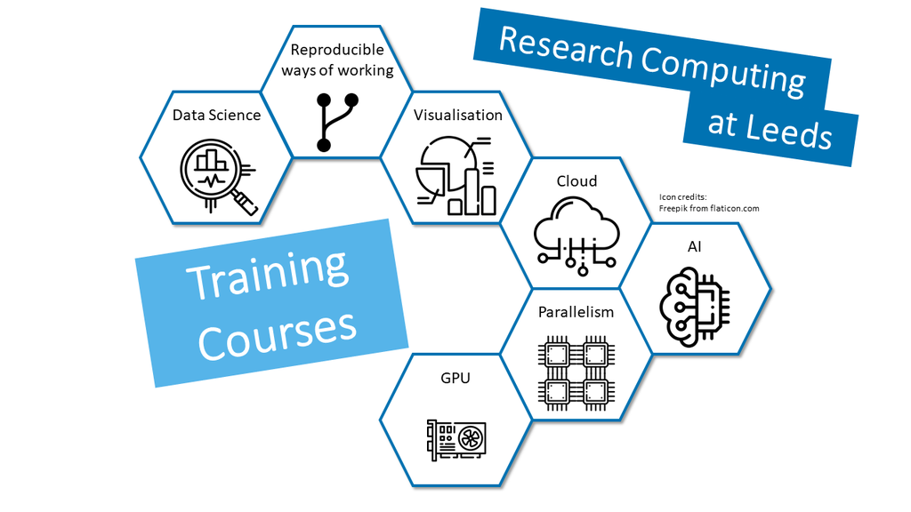

## Contents

1. Key differences between Arc and Aire
2. Access and logging-on
3. Basic Slurm configuration
4. Example job scripts
5. Storage management
6. Quotas and fair-use

Note that all links in this presentation will open in “preview mode”, meaning you can view pages without losing your place in the slideshow.

## Spot-the-difference

*How will using Aire be different?*

1. Goodbye SGE and hello Slurm! Son of Grid Engine is out, along with familiar commands such as `qsub`, `qstat`, and `qdel`
   - Thankfully, Slurm uses very similar config options, so it should be easy to port your jobs over.
   - Slurm is also widely used across other HPC systems, meaning your work is more portable and in-line with other HPC research.
2. A new storage system configuration - goodbye `/nobackup` and hello `$SCRATCH`, our new disk-based parallel Lustre filesystem, optimised for HPC workloads!
   - Your scratch directory is at `/mnt/scratch/<username>`, but can be accessed using the environment variable: `cd $SCRATCH`
   - As on Arc, this area is **not backed up** and deleted files cannot be recovered
   - Unlike Arc, files in this areas **do not** automatically expire after 90 days without use
   - This area has **per-user quotas**… more on the next slide!

## Access and Logging-on

We’ve written a series of [**knowledge base articles**](https://arcdocs.leeds.ac.uk/aire/getting_started/logging_on.html) guiding you on how to log-on from different devices.

From off-site, we recommend connecting through the University’s ssh gateway `rash`:

```bash
ssh <username>@aire.leeds.ac.uk -J <username@rash.leeds.ac.uk
```

- You’ll need to be registered to use `rash`
- You’ll need to have a Duo authentication method on-hand to connect.

To slow connection timeout, add a “keepalive” command to your SSH user config file: `ServerAliveInterval 60`. Check out the [KB article on the SSH gateway to see other configuration options](https://it.leeds.ac.uk/it?id=kb_article&sys_id=e787b3561bd34ad4ba670ed0f54bcb17&spa=1).

## Basic Slurm configuration

Instead of using Son of Grid Engine (SGE) scheduler, Aire uses Slurm.

From a user perspective, this works in a very similar way to how you’re used to using HPC at Leeds.

| **Old SGE command** | **New Slurm command** | **Slurm docs** |
| --- | --- | --- |
| `qsub` | `sbatch` | [Submit a batch job script](https://slurm.schedmd.com/sbatch.html) |
| `qstat` | `squeue` | [Check job queue status](https://slurm.schedmd.com/squeue.html) |
| `qdel` | `scancel` | [Cancel/delete a job](https://slurm.schedmd.com/scancel.html) |
| `qrsh` | `srun` | [Run an interactive job](https://slurm.schedmd.com/srun.html) |
| `qacct` | `sacct` | [Completed job info](https://slurm.schedmd.com/sacct.html) |

## Basic Slurm job scripts

General info

| **Old SGE setting** | **New Slurm setting** |
| --- | --- |
| **Task output files (`stdout` and `stderr`):** |  |
| `job_name.oJOBID.TASKID` `job_name.eJOBID.TASKID` | `slurm-JOBID_TASKID.out` |
| **Job script special line notation:** |  |
| `#$` | `#SBATCH` |
| **Basic job array, asking for 50 tasks:** |  |
| `#$ -t 1-50` | `#SBATCH -a 1-50` |

## Basic Slurm job scripts - some examples

Let’s look at some [example job scripts!](https://arcdocs.leeds.ac.uk/aire/usage/job_example.html)

## Storage management

| **ARC4 setting** | **Aire setting** |
| --- | --- |
| **Home directory quota:** |  |
| 10GB, no file number quota | 30GB, 1 million files |
| **HPC I/O storage quota:** |  |
| `/nobackup` No quota | `$SCRATCH` 1TB, 1.5 million files Can be increased if required. |

## Quotas and Fair Use

**Why?**

- A larger home directory means that you can store things like conda environments there more easily. See [our documentation on conda environments here.](https://arcdocs.leeds.ac.uk/aire/usage/dependency_management.html)
  - This is more efficient, as the Lustre filesystem on `$SCRATCH` is not optimised for handling lots of small files as required by a conda environment.
  - You will likely still need to regularly tear down/rebuild conda environments; treat your environments as disposable.
- A generous quota on `$SCRATCH` means that we won’t run into the frequent issues seen on `/nobackup` where the system was halted by a few intesive users creating huge files:
  - A very small percent of our users will reach the quota (given records of ARC3 and 4 use);
  - This quota can be increased if needed, on reasonable request.

## Quotas and Fair use

- Remember that this is a shared resource!
  - Waiting for your turn in the queue is part of the process in using a shared resource.
  - Request sensible resources for your jobs, reducing requests if following a job you see that you did not use all the resources allocated: this can improve your queueing time.
  - Do **not** use the login nodes for computationally intensive tasks; this degrades performance for everyone.
- Ensure you use your storage effectively and efficiently:
  - Do **not** use your home directory for job I/O as this can degrade performance for all users.
  - Where possible, store files such as conda environments in your home directory.
  - Do not use `$SCRATCH` as permanent research storage:
    - Data can be held on `$SCRATCH` for the duration of your research, but remember that it **IS NOT BACKED UP** and may be wiped with short notice.

## Finding support and help

Please look at [our documentation](https://arcdocs.leeds.ac.uk/aire/support/start.html) for general guidance and links to different ways of contacting us for support!